# Lab 5 Prep: Logistic Regression

## Introduction

Logistic regression, also called a logit model, is used to model dichotomous outcome variables. In a logistic regression the *log odds* of the outcome/response is modeled as a linear combination of the predictor variables. In this example, we are interested in how variables, such as GRE (Graduate Record Exam scores), GPA (grade point average) and prestige of the undergraduate institution, effect admission into graduate school. The response variable, admit/don’t admit, is a binary variable. We will be working with [hypothetical data](http://www.ats.ucla.edu/stat/data/binary.csv) generated for the purposes of this exercise.

```r
mydata = read.csv("http://www.ats.ucla.edu/stat/data/binary.csv")
head(mydata)  # View the first few rows of the data
```

```
##   admit gre  gpa rank
## 1     0 380 3.61    3
## 2     1 660 3.67    3
## 3     1 800 4.00    1
## 4     1 640 3.19    4
## 5     0 520 2.93    4
## 6     1 760 3.00    2
```

This dataset has a binary response (outcome, dependent) variable called `admit`. There are three predictor variables: `gre`, `gpa`, and `rank`. We will treat the variables `gre` and `gpa` as continuous. The variable `rank` takes on the values `1` through `4`. Institutions with a `rank` of `1` have the highest ‘prestige’, while those with a `rank` of `4` have the lowest.

## Getting Started

As usual, we can get basic descriptive statistics for the entire data set by using `summary`. To get the standard deviations, we can use `sapply` to apply the `sd` function to each variable in the dataset.

```r
summary(mydata)
```

```
##      admit             gre             gpa             rank
##  Min.   :0.0000   Min.   :220.0   Min.   :2.260   Min.   :1.000
##  1st Qu.:0.0000   1st Qu.:520.0   1st Qu.:3.130   1st Qu.:2.000
##  Median :0.0000   Median :580.0   Median :3.395   Median :2.000
##  Mean   :0.3175   Mean   :587.7   Mean   :3.390   Mean   :2.485
##  3rd Qu.:1.0000   3rd Qu.:660.0   3rd Qu.:3.670   3rd Qu.:3.000
##  Max.   :1.0000   Max.   :800.0   Max.   :4.000   Max.   :4.000
```

```r
sapply(mydata, sd)
```

```
##       admit         gre         gpa        rank
##   0.4660867 115.5165364   0.3805668   0.9444602
```

It is also always a good idea to take a look at the relationship between our response variable and our various predictors. This can usualy be done via the generic `plot` command on a (subset of a) dataset, however, with a binary outcome such as `admit`, it may be preferable to compare the various variables using boxplots:

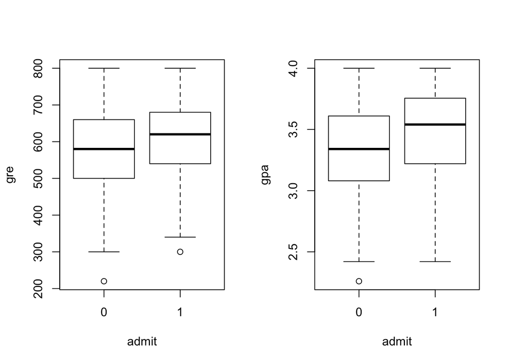

```r
boxplot(gre ~ admit, data=mydata)
boxplot(gpa ~ admit, data=mydata)
```

It is less obvious how we would plot a categorical variable such as `rank` with a binary response such as `admit`. In this case, it is always a good idea to check for empty or small cells by doing a cross-tab between any categorical predictors and the outcome variable. If a cell has very few cases (a small cell), the model may become unstable or it might not run at all:

```r
# Two-way contingency table (crosstab) of outcome and categorical predictor(s)
xtabs(~ admit + rank, data=mydata)
```

```
##      rank
## admit  1  2  3  4
##     0 28 97 93 55
##     1 33 54 28 12
```

Think about other exploratory methods and plots that you can use to characterize the potential relationhips you will be exploring.

## Fitting models

The code below estimates a logistic regression model using the `glm` (generalized linear model) function. First, we convert `rank` to a factor to indicate that `rank` should be treated as a categorical variable:

```r
mydata$rank = factor(mydata$rank)
mylogit = glm(admit ~ gre + gpa + rank, data=mydata, family="binomial")
```

We can get the summary of this model in the usual way:

```r
summary(mylogit)
```

```
##
## Call:
## glm(formula = admit ~ gre + gpa + rank, family = "binomial",
##     data = mydata)
##
## Deviance Residuals:
##     Min       1Q   Median       3Q      Max
## -1.6268  -0.8662  -0.6388   1.1490   2.0790
##
## Coefficients:
##              Estimate Std. Error z value Pr(>|z|)
## (Intercept) -3.989979   1.139951  -3.500 0.000465 ***
## gre          0.002264   0.001094   2.070 0.038465 *
## gpa          0.804038   0.331819   2.423 0.015388 *
## rank2       -0.675443   0.316490  -2.134 0.032829 *
## rank3       -1.340204   0.345306  -3.881 0.000104 ***
## rank4       -1.551464   0.417832  -3.713 0.000205 ***
## ---
## Signif. codes:  0 '***' 0.001 '**' 0.01 '*' 0.05 '.' 0.1 ' ' 1
##
## (Dispersion parameter for binomial family taken to be 1)
##
##     Null deviance: 499.98  on 399  degrees of freedom
## Residual deviance: 458.52  on 394  degrees of freedom
## AIC: 470.52
##
## Number of Fisher Scoring iterations: 4
```

Note that there are several major differences between the `summary` output for a `glm` and an `lm` model. Let’s break the above output down in order to get a better idea of what is going on here:

- The first thing we see is the call, this is `R` reminding us what the model we ran was, what options we specified, etc. Same as `lm`.
- Next we see the deviance residuals, which are a measure of model fit. This part of the output shows the distribution of the deviance residuals for individual cases used in the model. Below we’ll discuss how to use summaries of the deviance statistic to assess model fit.
- The next part of the output shows the coefficients, their standard errors, the z-statistic (sometimes called a *Wald* z-statistic), and the associated p-values.
  - Both `gre` and `gpa` are statistically significant, as are the three terms for `rank`.
  - The logistic regression coefficients give the change in the *log odds* of the outcome for a one unit increase in the predictor variable, so we need to be careful when we interpret these values:
    - For every one unit change in `gre`, the log odds of admission (versus non-admission) increases by `0.002`.
    - For a one unit increase in `gpa`, the log odds of being admitted to graduate school increases by `0.804`.
    - The indicator variables for `rank` have a slightly different interpretation. For example, having attended an undergraduate institution with `rank` of `2`, versus an institution with a `rank` of `1`, changes the log odds of admission by `-0.675`.
- Below the table of coefficients are fit indices, including the null and deviance residuals and the AIC. Later we show an example of how you can use these values to help assess model fit.

We can use the `confint` function to obtain confidence intervals for the coefficient estimates. Note that for logistic models, confidence intervals are based on the profiled log-likelihood function. We can also get CIs based on just the standard errors by using the ‘default’ method:

```r
# CIs using profiled log-likelihood
confint(mylogit)
```

```
##                     2.5 %       97.5 %
## (Intercept) -6.2716202334 -1.792547080
## gre          0.0001375921  0.004435874
## gpa          0.1602959439  1.464142727
## rank2       -1.3008888002 -0.056745722
## rank3       -2.0276713127 -0.670372346
## rank4       -2.4000265384 -0.753542605
```

```r
# CIs using standard errors
confint.default(mylogit)
```

```
##                     2.5 %       97.5 %
## (Intercept) -6.2242418514 -1.755716295
## gre          0.0001202298  0.004408622
## gpa          0.1536836760  1.454391423
## rank2       -1.2957512650 -0.055134591
## rank3       -2.0169920597 -0.663415773
## rank4       -2.3703986294 -0.732528724
```

## Model Evaluation

You can also exponentiate the coefficients and interpret them as odds-ratios (we’ll discuss this in class). To get the exponentiated coefficients, you can simply exponentiate (`exp`) the output from the coefficients (`coef`) function. We can use the same logic to get odds ratios *and* their confidence intervals, by exponentiating the confidence intervals from before. To put it all in one table, we use `cbind` to bind the coefficients and confidence intervals column-wise:

```r
# Odds ratios only
exp(coef(mylogit))
```

```
## (Intercept)         gre         gpa       rank2       rank3       rank4
##   0.0185001   1.0022670   2.2345448   0.5089310   0.2617923   0.2119375
```

```r
# Odds ratios and 95% CI
# Note we're 'wrapping' the whole thing in `exp`
exp(cbind(OR = coef(mylogit), confint(mylogit)))
```

```
##                    OR       2.5 %    97.5 %
## (Intercept) 0.0185001 0.001889165 0.1665354
## gre         1.0022670 1.000137602 1.0044457
## gpa         2.2345448 1.173858216 4.3238349
## rank2       0.5089310 0.272289674 0.9448343
## rank3       0.2617923 0.131641717 0.5115181
## rank4       0.2119375 0.090715546 0.4706961
```

Now we can say that for a one unit increase in `gpa`, the odds of being admitted to graduate school (versus not being admitted) increase by a factor of `2.23`. Note that while `R` produces it, the odds ratio for the intercept is not generally interpreted.

You can also use predicted probabilities to help you understand the model. Predicted probabilities can be computed for both categorical and continuous predictor variables. In order to create predicted probabilities we first need to create a new `data.frame` with the values we want the independent variables to take on to create our predictions.

We will start by calculating the predicted probability of admission at each value of `rank`, holding `gre` and `gpa` at their means. First we create and view the `data.frame`:

```r
# Create, and ...
newdata1 = with(mydata,
  data.frame(gre=mean(gre), gpa=mean(gpa), rank=factor(1:4)))
# ... view the new data.frame
newdata1
```

```
##     gre    gpa rank
## 1 587.7 3.3899    1
## 2 587.7 3.3899    2
## 3 587.7 3.3899    3
## 4 587.7 3.3899    4
```

These objects must have the *same* names as the variables in your logistic regression above (e.g., in this example the mean for `gre` must be named `gre`). Now that we have the `data.frame` we want to use to calculate the predicted probabilities, we can tell `R` to create the predicted probabilities. The first line of code below is assigning a new variable (`rankP`) to the `newdata1` `data.frame` based on the output from the `predict( )` function. The options within the parentheses indicate that the predictions should be based on the `mylogit` model, with values of the predictor variables coming from `newdata1` and that the type of prediction is a predicted probability (`type="response"`).

```r
newdata1$rankP = predict(mylogit, newdata=newdata1, type="response")
newdata1
```

```
##     gre    gpa rank     rankP
## 1 587.7 3.3899    1 0.5166016
## 2 587.7 3.3899    2 0.3522846
## 3 587.7 3.3899    3 0.2186120
## 4 587.7 3.3899    4 0.1846684
```

In the above output we see that the predicted probability of being accepted into a graduate program is `0.52` for students from the highest prestige undergraduate institutions (`rank`=`1`), and `0.18` for students from the lowest ranked institutions (`rank`=`4`), holding `gre` and `gpa` at their means.

The above ‘experiments’ can also be conducted using the `makeFun` function from the `mosaic` package:

```r
library(mosaic)
f = makeFun(mylogit)
with(mydata,
     f(gre=mean(gre), gpa=mean(gpa), rank=factor(1:4)))
```

```
##         1         2         3         4
## 0.5166016 0.3522846 0.2186120 0.1846684
```

We may also wish to see measures of how well our model fits. This can be particularly useful when comparing competing models. The output produced by `summary(mylogit)` included indices of fit (shown below the coefficients), including the `null` and `deviance` residuals and the `AIC` (which is a good measure to compare models).

One measure of model fit is the significance of the overall model. This test asks whether the model with predictors fits significantly better than a model with just an intercept (i.e., a ‘null’ model). The test statistic is the difference between the residual deviance for the model with predictors and the null model. The test statistic is distributed chi-squared with degrees of freedom equal to the differences in degrees of freedom between the current and the null model (i.e., the number of predictor variables in the model). The package `lmtest` contains the function `lrtest` which will perform this test on our model:

```r
library(lmtest)
# We use this syntax (:::) as a workaround for 'masking'...
lmtest:::lrtest(mylogit)
```

```
## Likelihood ratio test
##
## Model 1: admit ~ gre + gpa + rank
## Model 2: admit ~ 1
##   #Df  LogLik Df  Chisq Pr(>Chisq)
## 1   6 -229.26
## 2   1 -249.99 -5 41.459  7.578e-08 ***
## ---
## Signif. codes:  0 '***' 0.001 '**' 0.01 '*' 0.05 '.' 0.1 ' ' 1
```

```r
waldtest(mylogit)  # A similar test (see ?waldtest)
```

```
## Wald test
##
## Model 1: admit ~ gre + gpa + rank
## Model 2: admit ~ 1
##   Res.Df Df      F    Pr(>F)
## 1    394
## 2    399 -5 7.2279 1.721e-06 ***
## ---
## Signif. codes:  0 '***' 0.001 '**' 0.01 '*' 0.05 '.' 0.1 ' ' 1
```

The chi-square of `41.46` with `5` degrees of freedom and an associated p-value of significantly less than `0.05` tells us that our model as a whole fits significantly better than an empty model. This is sometimes called a likelihood ratio test (the deviance residual is -2*log likelihood). If we were comparing multiple models (which you will in the lab), you can enter these into the `lrtest` and they will be compared via likelihood ratio tests (see `?lrtest` for details).

## Comparing Models

There are a few other tests you might want to consider… In reality, there are fewer diagnostics for GLMs than we have for OLS, however, these diagnostics tend to be a bit more difficult to interpret. We can specify ANOVA with `test="LRT"` to perform analisis of deviance tests, which for the most part, are equivalent to the tests shown above. For example, to test a full model with a null model in a way similar to the above `lrtest`, we can use:

```r
nullmod = glm(admit ~ 1, data=mydata, family="binomial")
anova(mylogit, nullmod, test="Chisq")  # This is identical to lrtest above!
```

```
## Analysis of Deviance Table
##
## Model 1: admit ~ gre + gpa + rank
## Model 2: admit ~ 1
##   Resid. Df Resid. Dev Df Deviance  Pr(>Chi)
## 1       394     458.52
## 2       399     499.98 -5  -41.459 7.578e-08 ***
## ---
## Signif. codes:  0 '***' 0.001 '**' 0.01 '*' 0.05 '.' 0.1 ' ' 1
```

Alternatively, we can look at the contributions of each variable in turn (like a type 1 anova), or explore which terms can be dropped from our model using the `drop1` function (see your class notes for details):

```r
anova(mylogit, test="LRT")
```

```
## Analysis of Deviance Table
##
## Model: binomial, link: logit
##
## Response: admit
##
## Terms added sequentially (first to last)
##
##
##      Df Deviance Resid. Df Resid. Dev  Pr(>Chi)
## NULL                   399     499.98
## gre   1  13.9204       398     486.06 0.0001907 ***
## gpa   1   5.7122       397     480.34 0.0168478 *
## rank  3  21.8265       394     458.52 7.088e-05 ***
## ---
## Signif. codes:  0 '***' 0.001 '**' 0.01 '*' 0.05 '.' 0.1 ' ' 1
```

```r
drop1(mylogit, test="LRT")
```

```
## Single term deletions
##
## Model:
## admit ~ gre + gpa + rank
##        Df Deviance    AIC     LRT  Pr(>Chi)
## <none>      458.52 470.52
## gre     1   462.88 472.88  4.3578   0.03684 *
## gpa     1   464.53 474.53  6.0143   0.01419 *
## rank    3   480.34 486.34 21.8265 7.088e-05 ***
## ---
## Signif. codes:  0 '***' 0.001 '**' 0.01 '*' 0.05 '.' 0.1 ' ' 1
```

When building models, you may want to compare your models with one another using `AIC`, `lrtest` and/or `anova`:

```r
anova(full_mod, sub_mod, test="Chisq")
```

In general, you want to follow these guidelines:

- Identify the questions of interest
- Build models that include terms to answer questions via hypothesis tests and parameter estimates
- Examine the need for extra terms as a way to assess model fit and adequacy.
- Examine the effect of single variables (odds ratios, tests of significance).
- Use analysis of deviance (drop in deviance) to compare full and reduced models to assess the contribution of several variables.
- Easiest way is to look at the model “goodness of fit” statistic (AIC, Deviance, etc.).
- LRT or drop in deviance test using `anova()`

## Extras

While there is no R-squared measure for GLMs, many different measures of *psuedo*-R-squared exist. They all attempt to provide information similar to that provided by R-squared in OLS regression; however, none of them can be interpreted exactly as R-squared in OLS regression is interpreted. The `pscl` package in `R` provides a nice tool to compute several psuedo-R-squared measures (try `?pR2` to learn more):

```r
## pscl also has a predprob function for computing predicted probabilities
# predprob(mylogit, newdata = newdata1)
library(pscl)
pR2(mylogit)
```

```
##           llh       llhNull            G2      McFadden          r2ML
## -229.25874624 -249.98825878   41.45902508    0.08292194    0.09845702
##          r2CU
##    0.13799580
```

Another package worth checking out is the `rms` package, by Frank Harrell. You’ll find everything you need for fitting and validating GLMs. Try installing it and using the `lrm` function instead of the `glm` function (they are basically the same, with `lrm` providing more information specific to logistic regression models):

```r
# Warning, there is a lrtest in this package
# that will 'mask' the one in the lmtest package...
# see above lrtest for a workaround
library(rms)
mylrm = lrm(admit ~ gre + gpa + rank, data=mydata)  # Don't need family argument
mylrm
```

```
##
## Logistic Regression Model
##
## lrm(formula = admit ~ gre + gpa + rank, data = mydata)
##                       Model Likelihood     Discrimination    Rank Discrim.
##                          Ratio Test            Indexes          Indexes
## Obs           400    LR chi2      41.46    R2       0.138    C       0.693
##  0            273    d.f.             5    g        0.838    Dxy     0.386
##  1            127    Pr(> chi2) <0.0001    gr       2.311    gamma   0.387
## max |deriv| 2e-06                          gp       0.167    tau-a   0.168
##                                            Brier    0.195
##
##           Coef    S.E.   Wald Z Pr(>|Z|)
## Intercept -3.9900 1.1400 -3.50  0.0005
## gre        0.0023 0.0011  2.07  0.0385
## gpa        0.8040 0.3318  2.42  0.0154
## rank=2    -0.6754 0.3165 -2.13  0.0328
## rank=3    -1.3402 0.3453 -3.88  0.0001
## rank=4    -1.5515 0.4178 -3.71  0.0002
```

Note the ‘Model Likelihood Ratio Test’ similar to above, as well as the Discrimination Indexes, which are psudo-R squared tests (see `?lrm` for more details).

## Notes

The purpose of this lab prep is to show how to use various data analysis commands. It does *not* cover all aspects of the research process which researchers are expected to do. In particular, it does not cover exploratory data analysis, model building, and scientific writing. It is here to help *prepare* for the lab, but it does *not* provide a perfect recipe for the lab.

### Reference

This lab prep has been adapted from an [R Data Analysis Example on Logistic Regression](http://www.ats.ucla.edu/stat/r/dae/logit.htm) developed by the UCLA Statistical Consulting Group.